# Časové řady – Seminární práce

### Vyhlazení pomocí exponenciálního vyrovnání

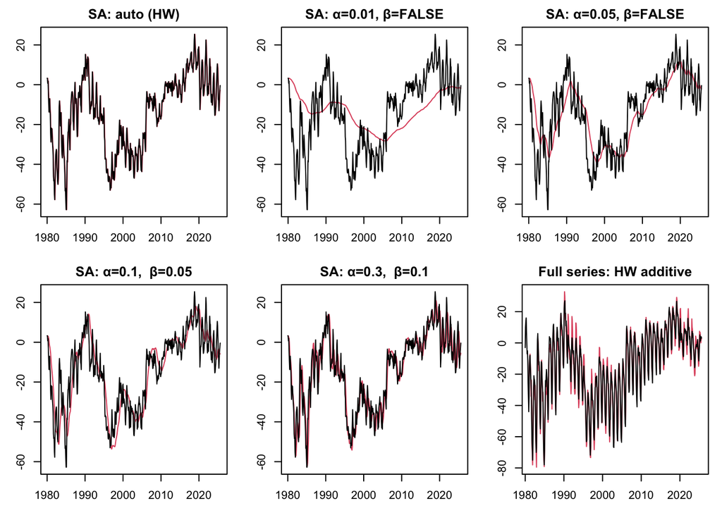

```r
rada.sa <- rada.ts - rada.dec$seasonal
rada.sa.exp     <- HoltWinters(rada.sa, gamma = FALSE) # základní dvojité exponenciální vyrovnání (HW bez sezónní složky)
# různé hodnoty parametrů alpha a beta
rada.sa.exp.a01 <- HoltWinters(rada.sa, alpha = 0.01, beta = FALSE, gamma = FALSE)
rada.sa.exp.a05 <- HoltWinters(rada.sa, alpha = 0.05, beta = FALSE, gamma = FALSE)
rada.sa.exp2    <- HoltWinters(rada.sa, alpha = 0.1,  beta = 0.05,  gamma = FALSE)
rada.sa.exp3    <- HoltWinters(rada.sa, alpha = 0.3,  beta = 0.1,   gamma = FALSE)

rada.hw.add     <- HoltWinters(rada.ts, seasonal = "additive")

oldpar <- par(no.readonly = TRUE)
par(mfrow = c(2,3), mar = c(3,3,2,1))

plot(rada.sa.exp,     main = "SA: auto (HW)")
plot(rada.sa.exp.a01, main = "SA: α=0.01, β=FALSE")
plot(rada.sa.exp.a05, main = "SA: α=0.05, β=FALSE")
plot(rada.sa.exp2,    main = "SA: α=0.1,  β=0.05")
plot(rada.sa.exp3,    main = "SA: α=0.3,  β=0.1")
plot(rada.hw.add,     main = "Full series: HW additive")
```

```r
par(oldpar)

SSE.tab <- data.frame(
  model = c("SA auto",
            "SA alpha=0.01, beta=FALSE",
            "SA alpha=0.05, beta=FALSE",
            "SA alpha=0.1, beta=0.05",
            "SA alpha=0.3, beta=0.1",
            "HW additive (full series)"),
  SSE   = c(rada.sa.exp$SSE,
            rada.sa.exp.a01$SSE,
            rada.sa.exp.a05$SSE,
            rada.sa.exp2$SSE,
            rada.sa.exp3$SSE,
            rada.hw.add$SSE)
)

SSE.tab <- SSE.tab[order(SSE.tab$SSE), ]
print(SSE.tab, row.names = FALSE)
```

```
                     model       SSE
                   SA auto  10573.24
 HW additive (full series)  14040.60
    SA alpha=0.3, beta=0.1  25802.23
   SA alpha=0.1, beta=0.05  47314.02
 SA alpha=0.05, beta=FALSE  68350.28
 SA alpha=0.01, beta=FALSE 161307.65
```

Pro odhad trendu byly použity různé varianty **Holt–Wintersova exponenciálního vyhlazení**. Nejprve jsme metodu aplikovali na **sezónně očištěnou řadu**, a to jak s automaticky odhadnutými parametry, tak s pevně zvolenými hodnotami α a β. Ukázalo se, že při velmi malém α je křivka příliš hladká a reaguje pomalu, zatímco při větších α a β model kopíruje i krátkodobé výkyvy. Nejlepších výsledků dosáhl **automatický model na SA řadě (SSE ≈ 10 600)**. Pro srovnání jsme dále použili **HW na původní sezónní řadě (aditivní varianta)**, který měl také poměrně dobrou chybu (SSE ≈ 14 000). Celkově lze říci, že **nejvhodnější je automatický HW na sezónně očištěné řadě**, i když aplikace na původní řadě potvrzuje podobný tvar trendu a funkčnost metody.

## iii. Hledání optimálního modelu pro samotnou řadu (funkční zápis trendu + sezónnost)

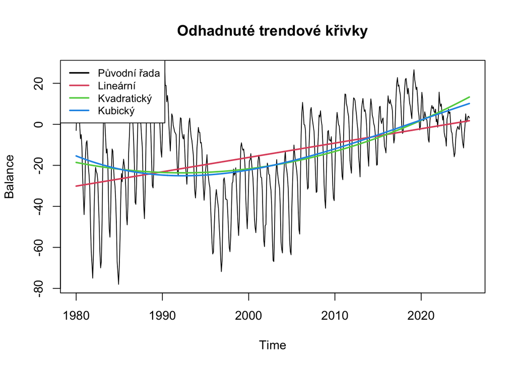

```r
 t <- as.numeric(time(rada.ts))   # skutečná časová osa z ts
y <- as.numeric(rada.ts)         # hodnoty řady

### Fit trendů (jen v závislosti na t)
mod_lin <- lm(y ~ t)
mod_kv  <- lm(y ~ t + I(t^2))
mod_kub <- lm(y ~ t + I(t^2) + I(t^3))

### Graf
plot(t, y, type = "l",
     main = "Odhadnuté trendové křivky",
     xlab = "Time", ylab = "Balance")
lines(t, fitted(mod_lin), col = 2, lwd = 2)
lines(t, fitted(mod_kv),  col = 3, lwd = 2)
lines(t, fitted(mod_kub), col = 4, lwd = 2)
legend("topleft",
       legend = c("Původní řada", "Lineární", "Kvadratický", "Kubický"),
       col = c(1,2,3,4), lty = 1, lwd = 2, cex = 0.85)
```

Na grafu jsou porovnány **lineární, kvadratický a kubický** trend s původní časovou řadou.

- **Lineární trend** (červeně) ukazuje jen postupný růst a nezachycuje obraty.
- **Kvadratický a kubický trend** (zeleně, modře) lépe vystihují pokles kolem roku 2000 a následný růst po roce 2010.
- Celkově je vidět, že **polynomy vyššího řádu vystihují vývoj lépe než čistě lineární trend**.

```r
### Stejné trendy + sezónní dummy (měsíce)
mesic <- factor(cycle(rada.ts))  # 12 kategorií
mod_lin_seas <- lm(y ~ t + mesic)
mod_kv_seas  <- lm(y ~ t + I(t^2) + mesic)
mod_kub_seas <- lm(y ~ t + I(t^2) + I(t^3) + mesic)


### Srovnání kvality trendů
cat("Lineární \ Kvadratický \ Kubický: \n")
```

```
Lineární  Kvadratický  Kubický:
```

```r
cat("R^2:", summary(mod_lin)$r.squared,
    summary(mod_kv)$r.squared,
    summary(mod_kub)$r.squared, "\n")
```

```
R^2: 0.176813 0.2329242 0.2359561
```

```r
cat("AIC:", AIC(mod_lin), AIC(mod_kv), AIC(mod_kub), "\n")
```

```
AIC: 4838.633 4801.945 4801.775
```

```r
cat("BIC:", BIC(mod_lin), BIC(mod_kv), BIC(mod_kub), "\n")
```

```
BIC: 4851.552 4819.17 4823.306
```

```r
cat("AIC se sezónností:",
    AIC(mod_lin_seas), AIC(mod_kv_seas), AIC(mod_kub_seas), "\n")
```

```
AIC se sezónností: 4613.791 4559.552 4558.039
```

```r
cat("BIC se sezónností:",
    BIC(mod_lin_seas), BIC(mod_kv_seas), BIC(mod_kub_seas), "\n")
```

```
BIC se sezónností: 4674.079 4624.146 4626.939
```

Byly vyzkoušeny lineární, kvadratický a kubický trend. Bez sezónnosti měly všechny modely poměrně nízkou vysvětlující schopnost (R² pod 25 %). Po přidání sezónních dummy proměnných se kvalita modelů výrazně zlepšila – AIC kleslo zhruba o 250 bodů. Nejlepší výsledky měl kvadratický a kubický trend se sezónní složkou, přičemž rozdíly mezi nimi byly malé. Lze tedy říci, že **optimálním funkčním zápisem je kvadratický/kubický trend doplněný o sezónní dummy proměnné**.

## iv. Hledání optimálního modelu typu SARIMA

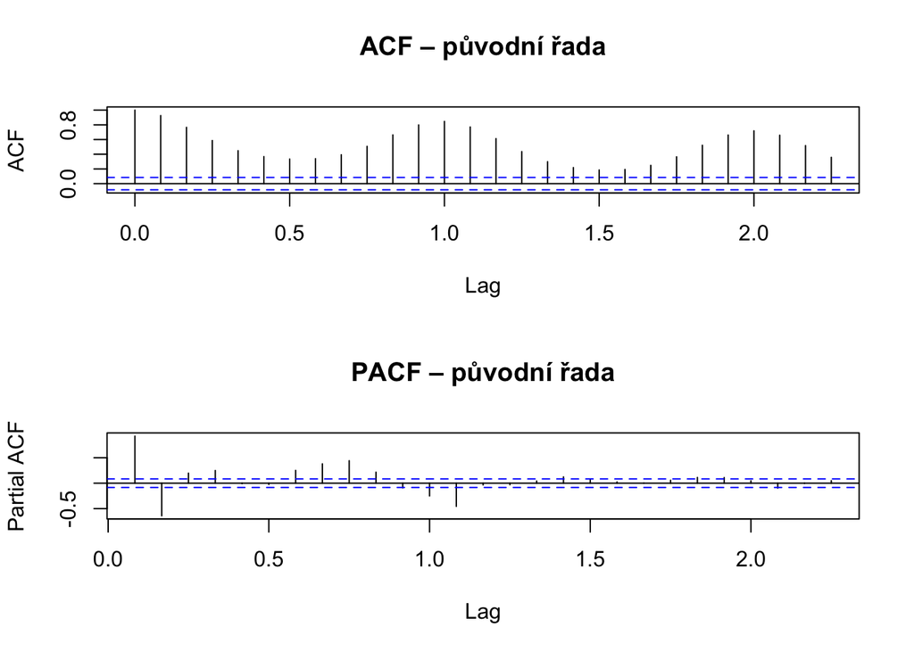

```r
## Hledání optimálního modelu typu SARIMA (měsíční data, perioda 12)

### ACF/PACF původní řady
par(mfrow = c(2,1))
acf(rada.ts,  na.action = na.pass, main = "ACF – původní řada")
pacf(rada.ts, na.action = na.pass, main = "PACF – původní řada")
```

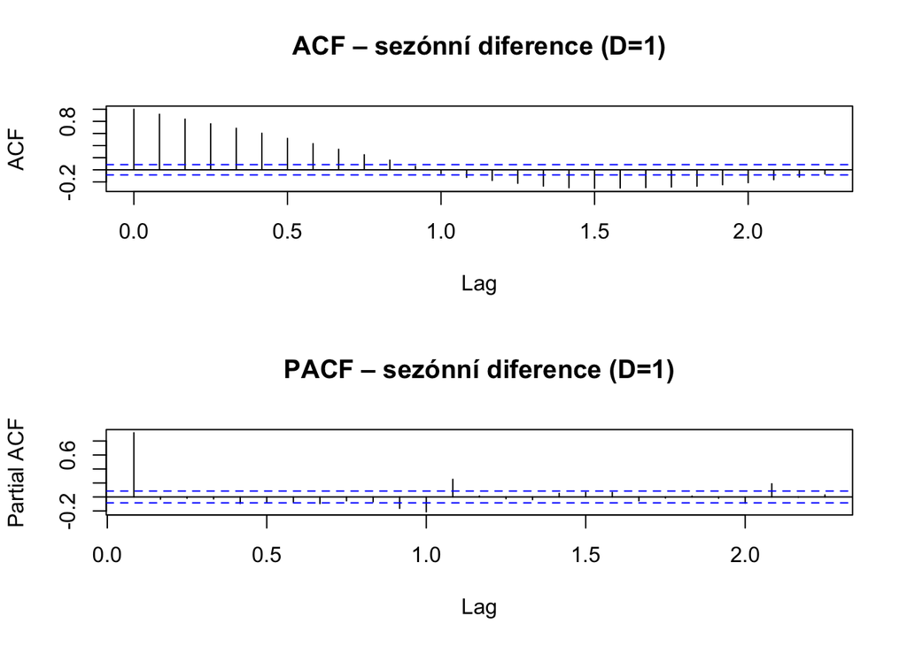

```r
par(mfrow = c(1,1))

rada.sdiff <- diff(rada.ts, lag = 12)                 # D=1
par(mfrow = c(2,1))
acf(rada.sdiff,  na.action = na.pass, main = "ACF – sezónní diference (D=1)")
pacf(rada.sdiff, na.action = na.pass, main = "PACF – sezónní diference (D=1)")
```

```r
par(mfrow = c(1,1))
rada.dd <- diff(rada.ts, differences = 1)             # d=1
rada.ddsd <- diff(rada.dd, lag = 12)                  # d=1, D=1
# acf(rada.ddsd); pacf(rada.ddsd)


fit1 <- Arima(rada.ts, order = c(0,0,0), seasonal = list(order = c(1,1,1), period = 12))
fit2 <- Arima(rada.ts, order = c(1,0,0), seasonal = list(order = c(1,1,1), period = 12))
fit3 <- Arima(rada.ts, order = c(0,0,1), seasonal = list(order = c(1,1,1), period = 12))
fit4 <- Arima(rada.ts, order = c(1,0,1), seasonal = list(order = c(1,1,1), period = 12))
fit5 <- Arima(rada.ts, order = c(2,0,0), seasonal = list(order = c(1,1,1), period = 12))
fit6 <- Arima(rada.ts, order = c(0,0,2), seasonal = list(order = c(1,1,1), period = 12))
fit7 <- Arima(rada.ts, order = c(0,1,1), seasonal = list(order = c(1,1,1), period = 12))
fit8 <- Arima(rada.ts, order = c(1,1,1), seasonal = list(order = c(1,1,1), period = 12))

fit.auto.aic <- auto.arima(rada.ts, seasonal = TRUE)            # default AIC
fit.auto.bic <- auto.arima(rada.ts, seasonal = TRUE, ic = "bic")

### Srovnání podle AIC, BIC
mods <- list(
  "SARIMA(0,0,0)x(1,1,1)[12]" = fit1,
  "SARIMA(1,0,0)x(1,1,1)[12]" = fit2,
  "SARIMA(0,0,1)x(1,1,1)[12]" = fit3,
  "SARIMA(1,0,1)x(1,1,1)[12]" = fit4,
  "SARIMA(2,0,0)x(1,1,1)[12]" = fit5,
  "SARIMA(0,0,2)x(1,1,1)[12]" = fit6,
  "SARIMA(0,1,1)x(1,1,1)[12]" = fit7,
  "SARIMA(1,1,1)x(1,1,1)[12]" = fit8,
  "auto.arima (AIC)"           = fit.auto.aic,
  "auto.arima (BIC)"           = fit.auto.bic)

crit <- data.frame(
  model = names(mods),
  AIC   = sapply(mods, AIC),
  BIC   = sapply(mods, BIC),
  logLik= sapply(mods, logLik))
crit <- crit[order(crit$BIC), ]   # seřadíme typicky podle BIC
print(crit, row.names = FALSE)
```

```
                     model      AIC      BIC    logLik
 SARIMA(0,1,1)x(1,1,1)[12] 3004.123 3021.252 -1498.061
 SARIMA(1,0,0)x(1,1,1)[12] 3004.594 3021.731 -1498.297
 SARIMA(2,0,0)x(1,1,1)[12] 3000.494 3021.914 -1495.247
 SARIMA(1,0,1)x(1,1,1)[12] 3001.063 3022.483 -1495.531
 SARIMA(1,1,1)x(1,1,1)[12] 3004.187 3025.599 -1497.094
          auto.arima (BIC) 3006.092 3027.512 -1498.046
          auto.arima (AIC) 3002.439 3028.144 -1495.220
 SARIMA(0,0,2)x(1,1,1)[12] 3399.295 3420.715 -1694.647
 SARIMA(0,0,1)x(1,1,1)[12] 3649.517 3666.654 -1820.759
 SARIMA(0,0,0)x(1,1,1)[12] 4136.481 4149.333 -2065.240
```

```r
### Diagnostika residuí nejlepšího modelu
best <- fit7
coeftest(best)         # významnost koeficientů
```

```
z test of coefficients:

      Estimate Std. Error  z value  Pr(>|z|)
ma1   0.081532   0.043036   1.8945  0.058155 .
sar1  0.206577   0.076497   2.7005  0.006924 **
sma1 -0.774059   0.058146 -13.3123 < 2.2e-16 ***
---
Signif. codes:  0 '***' 0.001 '**' 0.01 '*' 0.05 '.' 0.1 ' ' 1
```